# Crecimiento Económico. Medio Ambiente

# Crecimiento Económico | Medio Ambiente y Crecimiento

## Factores

**Contaminación del aire**

- La contaminación del aire es uno de los mayores problemas ambientales y de salud del mundo. Se desarrolla en dos contextos: interior (doméstico) y exterior.

[interactive chart not shown]

## Factores

**Contaminación del aire**

- La contaminación del aire contribuye al 9% de las muertes a nivel mundial, esto varía del 2% al 15% según el país.

[interactive chart not shown]

## Factores

**Contaminación del aire**

- La contaminación del aire contribuye al 9% de las muertes a nivel mundial, esto varía del 2% al 15% según el país.

[interactive chart not shown]

## Factores

**Contaminación del aire**

- Las tasas de mortalidad por contaminación del aire son más altas en los países de ingresos bajos y medios.

[interactive chart not shown]

## Factores

**Contaminación del aire**

- Los países desarrollados son los que más contaminan.

[interactive chart not shown]

## Factores

**Contaminación del aire**

- Instituciones y políticas influyen en emisiones.

[interactive chart not shown]

## Factores

**Contaminación del aire**

- Instituciones y políticas influyen en emisiones.

[interactive chart not shown]

## Factores

**Contaminación del aire**

- Instituciones y políticas influyen en emisiones.

[interactive chart not shown]

## Factores

**La contaminación del aire exterior tiende a aumentar con la industrialización antes de disminuir**

- El concepto se basa en la relación entre la desigualdad de ingresos y el desarrollo económico descrita por Simon Kuznets.

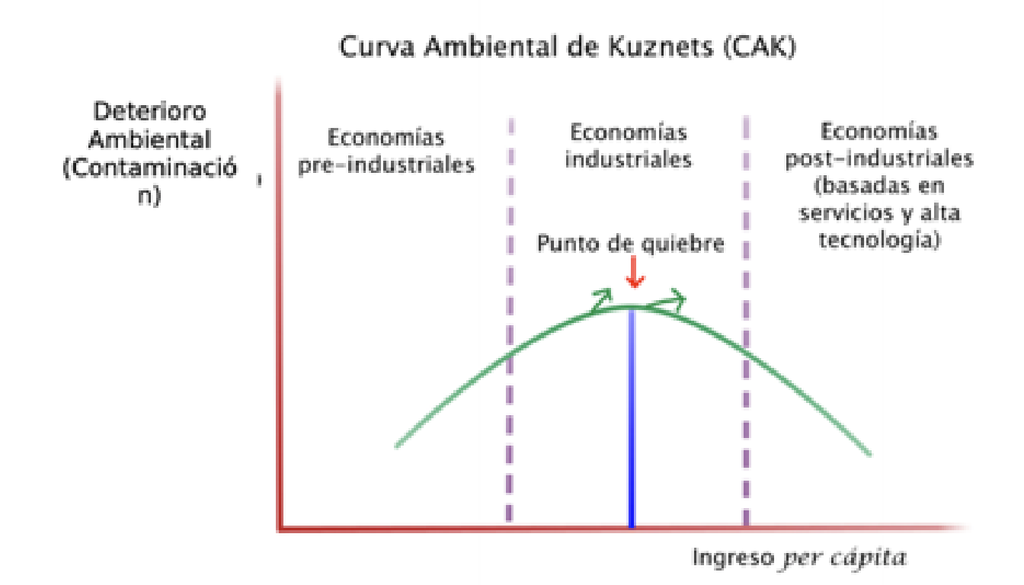

## Factores

**La contaminación del aire exterior tiende a aumentar con la industrialización antes de disminuir**

[interactive chart not shown]

## Preferencias

**Reexamining The Empirical Evidence For An Environmental Kuznets Curve (Harbaugh, Levinson y Wilson, 2002)**

- Descubren que hay muy poca evidencia empírica que apoye la teoría de la U invertida entre la relación contaminación y crecimiento económico.

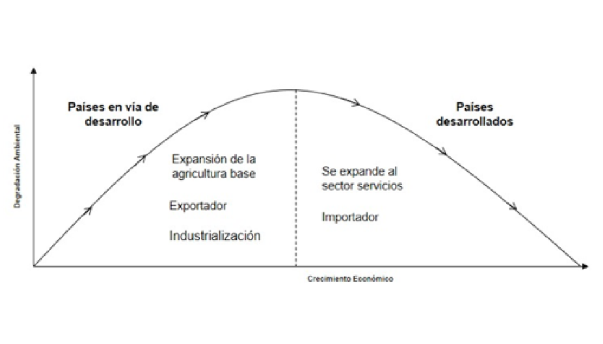

## Preferencias

**Reexamining The Empirical Evidence For An Environmental Kuznets Curve (Harbaugh, Levinson y Wilson, 2002)**

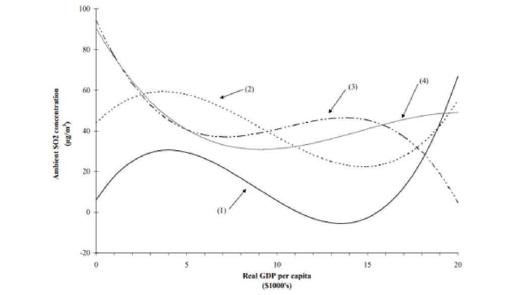

## Preferencias

**China and India lead in greening of the world through land-use management (Chen, et al., 2019)**

- El mundo es un lugar más verde de lo que era hace 20 años
- Producto de programas de reforestación en China y agricultura intensiva en China e India.
- China e India representan un tercio de este incremento.
- Contribución de China:
  - 42% producto de la reforestación
  - 32% producto del cultivo.

## Preferencias

**China and India lead in greening of the world through land-use management (Chen, et al., 2019)**

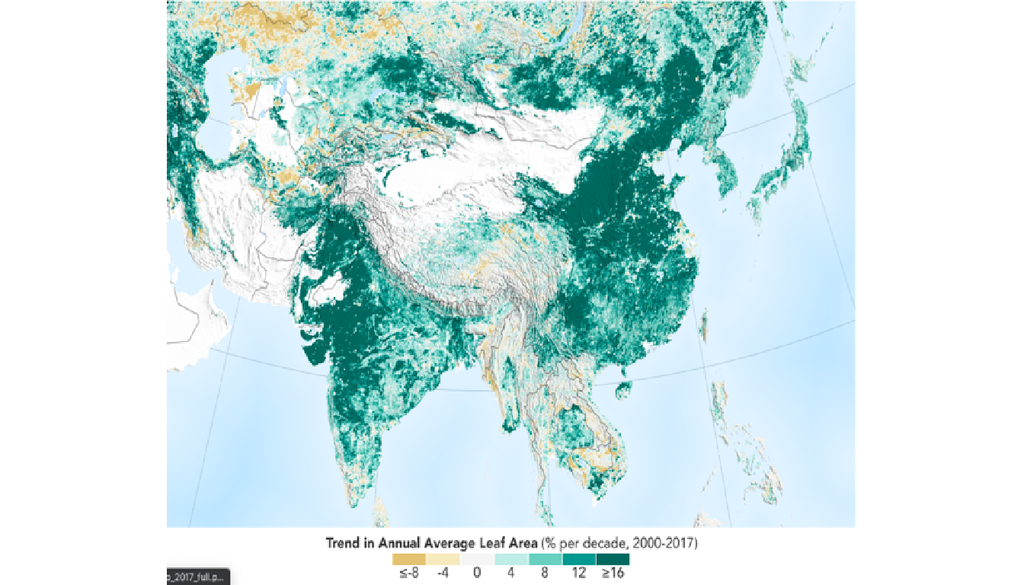

## Preferencias

**China and India lead in greening of the world through land-use management (Chen, et al., 2019)**

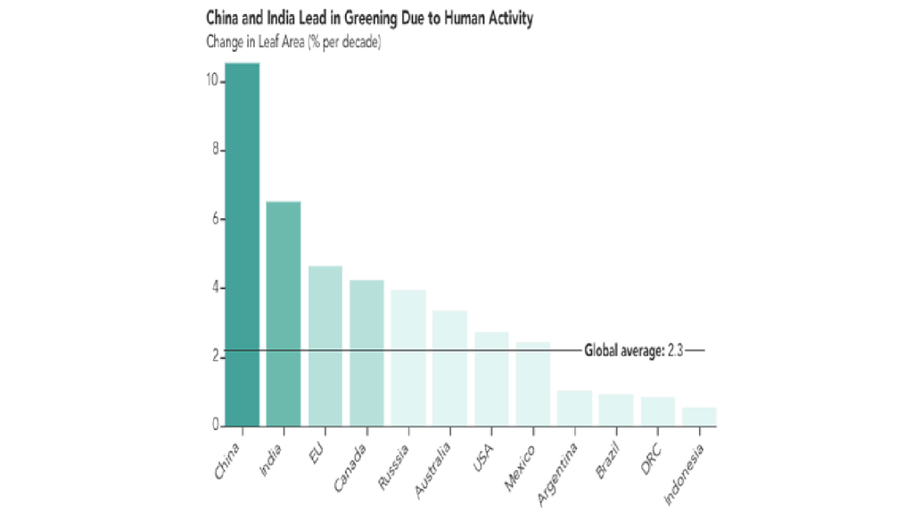

## Políticas

**The Environment and Directed Climate Change (Acemoglu, Aghion; 2012)**

- Análisis teórico y cuantitativo de regulación del medio ambiente
- ¿Cómo asegurar consumo y crecimiento económico?
- Extensión del modelo neoclásico de Ramsey

## Políticas

**The Environment and Directed Climate Change (Acemoglu, Aghion; 2012)**

- Modelo de crecimiento con restricciones medioambientales, donde se produce un único bien con insumos sucios y limpios e introducen un cambio tecnológico endógeno y dirigido
- La política óptima consiste en impuestos al carbón y subsidios a la I&D de energías limpias temporales que dirigen la innovación al sector limpio
  - Crecimiento sustentable es posible
  - Los insumos son sustitutos
  - De ser complementos, la intervención tendría que ser permanente y el crecimiento a largo plazo no sería posible

## Políticas

**The Environment and Directed Climate Change (Acemoglu, Aghion; 2012)**

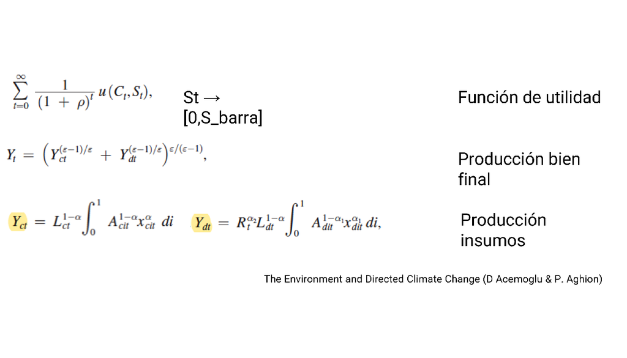

## Políticas

**The Environment and Directed Climate Change (Acemoglu, Aghion; 2012)**

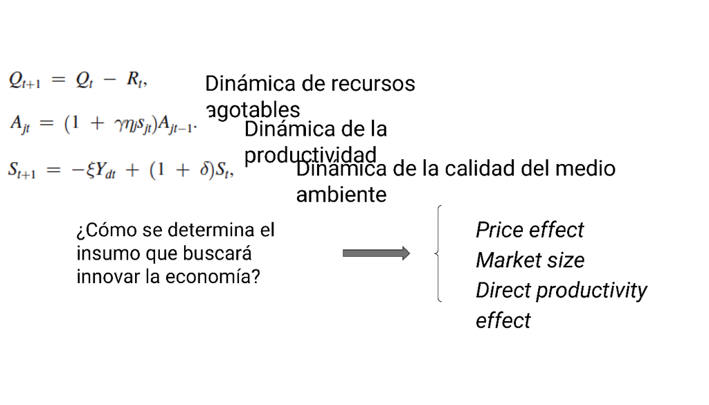

## Políticas

**The Environment and Directed Climate Change (Acemoglu, Aghion; 2012)**

- Herramientas: impuesto de carbono (carbon tax) y subsidio a la investigación
- Hay tres efectos importantes:
  - Efecto precio: impulsa a innovar donde los precios sean más altos
  - Efecto tamaño del mercado: incentiva a innovar en el mercado más grande
  - Efecto directo de la productividad: incentiva la innovación en el sector más productivo

## Políticas

**The Environment and Directed Climate Change (Acemoglu, Aghion; 2012)**

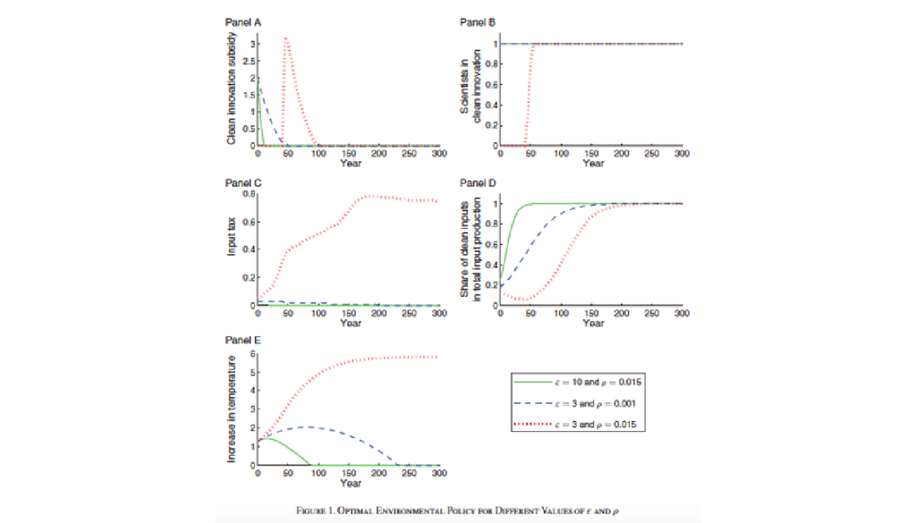

## Políticas

**The Environment and Directed Climate Change (Acemoglu, Aghion; 2012)**

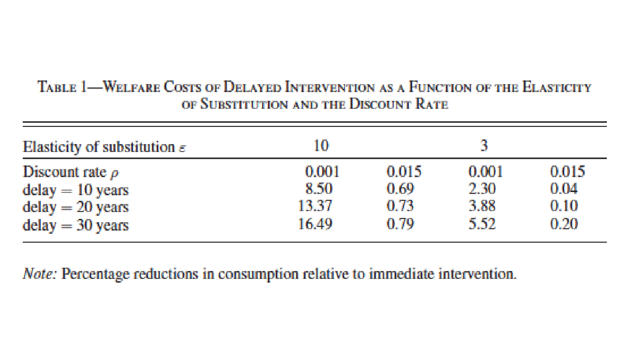

## Políticas

**The Environment and Directed Climate Change (Acemoglu, Aghion; 2012)**

- Es más costoso intervenir mañana que intervenir hoy
  - La degradación ambiental no se detiene
  - Cualquier intervención es costosa por el periodo de ajuste
  - El proceso será más tardado mientras más grande sea la brecha entre las productividades de los distintos sectores

## Políticas

**Carbon and Inequality: From Kyoto to Paris (Chancel y Piketty; 2015)**

- Desigualdades en la distribución global de emisiones de carbono han disminuido:
  - Los grupos de alto y mediano ingreso en los países en desarrollo crecieron
  - Desaceleración de crecimiento en países industrializados
  - Las desigualdades dentro de los países aumentaron

## Políticas

**Carbon and Inequality: From Kyoto to Paris (Chancel y Piketty; 2015)**

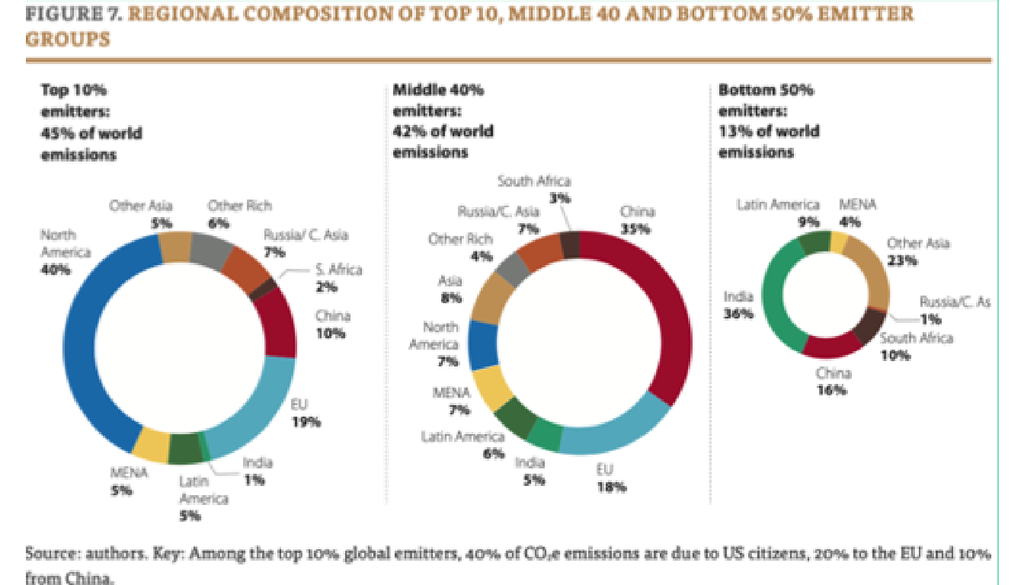

## Políticas

**Carbon and Inequality: From Kyoto to Paris (Chancel y Piketty; 2015)**

- Las emisiones siguen concentradas
- El 1% más rico de Estados Unidos, Luxemburgo, Singapur y Arabia Saudita son los mayores emisores del mundo, con emisiones per cápita anuales de dióxido de carbono

## Políticas

**Carbon and Inequality: From Kyoto to Paris (Chancel y Piketty; 2015)**

- En materia de mitigación, tanto países desarrollados cómo países en desarrollo contribuyen, pero no sucede lo mismo con el fondo para la adaptación.
- Proponen un impuesto global progresivo al carbón:
  - Estrategia 1: todos los individuos que emitan más dióxido de carbono (el promedio actual) deberán pagar un impuesto proporcional a sus emisiones
  - Estrategia 2: el impuesto se aplica al top 10% de los emisores en proporción a sus emisiones
  - Estrategia 3: el impuesto se aplica al top 1% de los emisores en proporción a sus emisiones
- Objetivo: juntar €150 miles de millones al año para el fondo de adaptación (la UNEP menciona que se necesitan 300 mil millones (billones) de euros anuales)

## Políticas

**Carbon and Inequality: From Kyoto to Paris (Chancel y Piketty; 2015)**

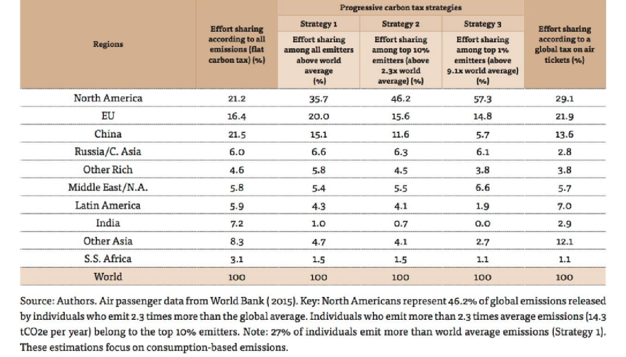

## Políticas

**Carbon and Inequality: From Kyoto to Paris (Chancel y Piketty; 2015)**

- Desventajas:
  - Implementar un impuesto global es muy complicado
  - Falta de cooperación
- Alternativa 1: Impuesto progresivo al carbón a nivel nacional
- Alternativa 2:
  - Poner un impuesto a ciertos bienes de consumo con altas emisiones. Ejemplo: boletos de avión
  - Ventaja: es fácil de implementar y existe cierta diferenciación entre emisores
  - Desventaja: no es la mejor opción para identificar a los mayores emisores